# Part I - Prosper Loan Dataset

## by (Andrew Bernard Ngari Mwangi)

## Table of Contents.

- Introduction
- Preliminary Wrangling
  - Preliminary Findings
- Univariate Exploration
  - Univariate Findings
- Bivariate Variables
  - Bivariate Findings
- Multivariate Variables
  - Multivariate Findings
- Conclusion

## Introduction

Prosper is a peer-to-peer lending marketplace. Through Prosper, people can invest in each other where borrowers apply online for a fixed-rate, fixed-term loan between $\$2,000$ and $\$40,000$. Individuals and institutions can invest in the loans and earn attractive returns. Prosper handles all loan servicing on behalf of the matched borrowers and investors.

## Preliminary Wrangling

```python
# import all packages and set plots to be embedded inline
import numpy as np
import pandas as pd
import matplotlib.pyplot as plt
import seaborn as sb

%matplotlib inline
```

```python
# Loading my dataset into a pandas dataframe and coping the dataset to another variable.
prosper_loan_data = pd.read_csv('prosperLoanData.csv')
prosper_loan = prosper_loan_data.copy()
prosper_loan.sample(5)
```

|  | ListingKey | ListingNumber | ListingCreationDate | CreditGrade | Term | LoanStatus | ClosedDate | BorrowerAPR | BorrowerRate | LenderYield | ... | LP_ServiceFees | LP_CollectionFees | LP_GrossPrincipalLoss | LP_NetPrincipalLoss | LP_NonPrincipalRecoverypayments | PercentFunded | Recommendations | InvestmentFromFriendsCount | InvestmentFromFriendsAmount | Investors |
| --- | --- | --- | --- | --- | --- | --- | --- | --- | --- | --- | --- | --- | --- | --- | --- | --- | --- | --- | --- | --- | --- |
| 74469 | 8CFD35161167476762C333F | 507702 | 43:20.8 | NaN | 36 | Current | NaN | 0.18173 | 0.1599 | 0.1499 | ... | -81.82 | 0.0 | 0.00 | 0.00 | 0.0 | 1.0 | 0 | 0 | 0.0 | 115 |
| 45285 | 313E35531299034415A7565 | 613870 | 23:28.5 | NaN | 36 | Chargedoff | 7/23/2013 0:00 | 0.24758 | 0.2099 | 0.1999 | ... | -22.11 | 0.0 | 3409.23 | 3409.23 | 0.0 | 1.0 | 0 | 0 | 0.0 | 56 |
| 53937 | FCE53600409635748204E13 | 1179693 | 32:39.2 | NaN | 36 | Current | NaN | 0.23438 | 0.1970 | 0.1870 | ... | -11.51 | 0.0 | 0.00 | 0.00 | 0.0 | 1.0 | 0 | 0 | 0.0 | 1 |
| 58580 | 60F435607318637986AA072 | 659388 | 25:46.0 | NaN | 36 | Current | NaN | 0.35797 | 0.3177 | 0.3077 | ... | -45.66 | 0.0 | 0.00 | 0.00 | 0.0 | 1.0 | 0 | 0 | 0.0 | 76 |
| 74117 | 0B4F342845697626643EA0F | 380665 | 43:11.0 | D | 36 | Completed | 10/14/2009 0:00 | 0.29334 | 0.2700 | 0.2600 | ... | -10.03 | 0.0 | 0.00 | 0.00 | 0.0 | 1.0 | 0 | 0 | 0.0 | 28 |

5 rows × 81 columns

```python
# Dropping the duplicates in the listing key column
prosper_loan.drop_duplicates(subset= 'ListingKey', inplace= True)
prosper_loan.ListingKey.duplicated().sum()
```

```
0
```

```python
prosper_loan.ListingNumber.duplicated().sum()
```

```
0
```

```python
print(prosper_loan.shape, prosper_loan.info())
```

```
<class 'pandas.core.frame.DataFrame'>
Int64Index: 113048 entries, 0 to 113936
Data columns (total 81 columns):
 #   Column                               Non-Null Count   Dtype
---  ------                               --------------   -----
 0   ListingKey                           113048 non-null  object
 1   ListingNumber                        113048 non-null  int64
 2   ListingCreationDate                  113048 non-null  object
 3   CreditGrade                          28947 non-null   object
 4   Term                                 113048 non-null  int64
 5   LoanStatus                           113048 non-null  object
 6   ClosedDate                           55067 non-null   object
 7   BorrowerAPR                          113023 non-null  float64
 8   BorrowerRate                         113048 non-null  float64
 9   LenderYield                          113048 non-null  float64
```

[output cut: 74 more lines]

```python
prosper_loan.describe()
```

|  | ListingNumber | Term | BorrowerAPR | BorrowerRate | LenderYield | EstimatedEffectiveYield | EstimatedLoss | EstimatedReturn | ProsperRating (numeric) | ProsperScore | ... | LP_ServiceFees | LP_CollectionFees | LP_GrossPrincipalLoss | LP_NetPrincipalLoss | LP_NonPrincipalRecoverypayments | PercentFunded | Recommendations | InvestmentFromFriendsCount | InvestmentFromFriendsAmount | Investors |
| --- | --- | --- | --- | --- | --- | --- | --- | --- | --- | --- | --- | --- | --- | --- | --- | --- | --- | --- | --- | --- | --- |
| count | 1.130480e+05 | 113048.000000 | 113023.000000 | 113048.000000 | 113048.000000 | 83970.000000 | 83970.000000 | 83970.000000 | 83970.000000 | 83970.000000 | ... | 113048.000000 | 113048.000000 | 113048.000000 | 113048.000000 | 113048.000000 | 113048.000000 | 113048.000000 | 113048.000000 | 113048.000000 | 113048.000000 |
| mean | 6.248000e+05 | 40.800722 | 0.218980 | 0.192945 | 0.182882 | 0.168869 | 0.080416 | 0.096246 | 4.068751 | 5.952995 | ... | -55.019382 | -14.350622 | 705.948712 | 686.787576 | 25.339209 | 0.998572 | 0.048342 | 0.023601 | 16.668963 | 80.881068 |
| std | 3.273146e+05 | 10.422025 | 0.080483 | 0.074917 | 0.074613 | 0.068608 | 0.046852 | 0.030475 | 1.675457 | 2.373886 | ... | 60.793252 | 109.650511 | 2397.076998 | 2365.635404 | 276.730464 | 0.017989 | 0.333281 | 0.232845 | 295.671045 | 103.344194 |
| min | 4.000000e+00 | 12.000000 | 0.006530 | 0.000000 | -0.010000 | -0.182700 | 0.004900 | -0.182700 | 1.000000 | 1.000000 | ... | -664.870000 | -9274.750000 | -94.200000 | -774.110000 | 0.000000 | 0.700000 | 0.000000 | 0.000000 | 0.000000 | 1.000000 |
| 25% | 3.976828e+05 | 36.000000 | 0.156290 | 0.134000 | 0.124500 | 0.116000 | 0.042400 | 0.074630 | 3.000000 | 4.000000 | ... | -73.490000 | 0.000000 | 0.000000 | 0.000000 | 0.000000 | 1.000000 | 0.000000 | 0.000000 | 0.000000 | 2.000000 |
| 50% | 5.978405e+05 | 36.000000 | 0.209840 | 0.184000 | 0.174000 | 0.161620 | 0.072400 | 0.092155 | 4.000000 | 6.000000 | ... | -34.790000 | 0.000000 | 0.000000 | 0.000000 | 0.000000 | 1.000000 | 0.000000 | 0.000000 | 0.000000 | 44.000000 |
| 75% | 8.849368e+05 | 36.000000 | 0.283860 | 0.250600 | 0.240600 | 0.225300 | 0.112000 | 0.117100 | 5.000000 | 8.000000 | ... | -14.180000 | 0.000000 | 0.000000 | 0.000000 | 0.000000 | 1.000000 | 0.000000 | 0.000000 | 0.000000 | 116.000000 |
| max | 1.255725e+06 | 60.000000 | 0.512290 | 0.497500 | 0.492500 | 0.319900 | 0.366000 | 0.283700 | 7.000000 | 11.000000 | ... | 32.060000 | 0.000000 | 25000.000000 | 25000.000000 | 21117.900000 | 1.012500 | 39.000000 | 33.000000 | 25000.000000 | 1189.000000 |

8 rows × 61 columns

```python
df = {'LoanStatus' : ['Current', 'Completed', 'FinalPaymentInProgress', 'Past Due (1-15 days)', 'Past Due (16-30 days)',
                      'Past Due (31-60 days)', 'Past Due (61-90 days)', 'Past Due (91-120 days)', 'Past Due (>120 days)',
                      'Defaulted', 'ChargedOff', 'Cancelled'],
      'IncomeRange' : ['$0', '$1-24,999', '$25,000-49,999', '$50,000-74,999', '$75,000-99,999', '$100,000+', 'Not displayed',
                       'Not employed'],
      'ProsperRating (Alpha)' : ['AA', 'A', 'B', 'C', 'D', 'E', 'HR'],
     'IsBorrowerHomeowner' : [True, False],
     'IncomeVerifiable' : [False, True]}


for var in df:
    ordered_df = pd.api.types.CategoricalDtype(ordered= True, categories= df[var])
    prosper_loan[var] = prosper_loan[var].astype(ordered_df)
```

```python
# Converting the LoanOriginationDate column from string to datetime using pandas.
prosper_loan['LoanOriginationDate'] = pd.to_datetime(prosper_loan.LoanOriginationDate)
```

### What is the structure of your dataset?

This dataset contains 113937 rows and 81 columns most of which have numerical type data. Other columns have the categorical type data while others have a date-time type data.

### What is/are the main feature(s) of interest in your dataset?

I'm most focused in getting to know how many investors get to lend loans based on the borrower's occupation, gender, their income range, their employment status, their state of residence, their stated monthly income et cetera.

### What features in the dataset do you think will help support your investigation into your feature(s) of interest?

The `ListingKey` showing the number of borrowers and the `Investors` column will help me support my investigation as it will give me a clue on how many investors get to invest based on most of the borrowers information.

## Univariate Exploration

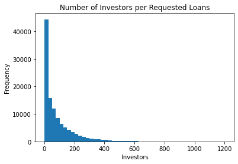

```python
# A histogram plot showing distribution of investors against frequency.
bins = np.arange(prosper_loan.Investors.min(), prosper_loan.Investors.max()+25, 25)
plt.hist(data=prosper_loan, x= 'Investors', bins= bins)
plt.xlabel('Investors')
plt.ylabel('Frequency')
plt.title('Number of Investors per Requested Loans');
```

In the above plot, it can be seen that the distribution of investors is skewed to the right with a large group of number of investors on the left while there's few of them on the right. I will therefore plot the histogram on a log scale and see how it affects the distribution of the dataset.

```
106.15866269185085
```

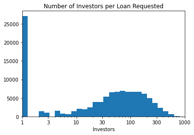

```python
# Average number of investors with borrowers who received loans from more than one investor.
print(prosper_loan[prosper_loan.Investors != 1].Investors.mean())

# Plotting the number of Investors lending loans per loan requested by use of a historam.
x = np.log10(prosper_loan.Investors.describe())
bins = 10 ** np.arange(x.min(), x.max() + 0.1, 0.1)
plt.hist(data= prosper_loan, x= 'Investors', bins= bins)
plt.xscale('log')
x_ticks = [1, 3, 10, 30, 100, 300, 1000]
plt.xticks(ticks= x_ticks, labels= x_ticks)
plt.xlim(1, 1000)
plt.xlabel('Investors')
plt.title('Number of Investors per Loan Requested');
```

On plotting the `Investors` column on a log scale, the distribution is bi-modal, with a majority of the group at the one mark and the second group of investors clustered around the 100 mark.

```python
# These are functions defined to plot Bar Graphs of Univariate plots using Seaborn's Countplot function.

def bar_texts(var, x, **kwargs):
    prosper = var.value_counts()
    base_color = sb.color_palette()[0]
    ax = plt.figure(figsize= (8, 6)).subplots()
    sb.countplot(data= prosper_loan, x= x, y= None, hue= None, color= base_color);
    ax.spines['top'].set_visible(False)
    ax.spines['right'].set_visible(False)

    locs, labels  = plt.xticks(rotation= 30)

    for loc, label in zip(locs, labels):
        count = prosper[label.get_text()]
        percentage = '{:.2f}%'.format((count * 100) / prosper.sum())
        m = plt.text(loc, count, percentage, ha= 'center', va= 'baseline')
    return m

def barh_texts(var, y, **kwargs):
    prosper = var.value_counts()
    base_color = sb.color_palette()[0]
    ax = plt.figure(figsize= (8, 6)).subplots()
    sb.countplot(data= prosper_loan, y= y, color= base_color);
    ax.spines['top'].set_visible(False)
    ax.spines['right'].set_visible(False)

    locs, labels = plt.yticks()

    for loc, label in zip(locs, labels):
        count = prosper[label.get_text()]
        percentage = '{:.2f}%'.format((count * 100) / prosper.sum())
        m = plt.text(count, loc, percentage, va= 'center', ha= 'left')
```

I am now going to make plot of both univariate categorical and numerical data in the dataset.

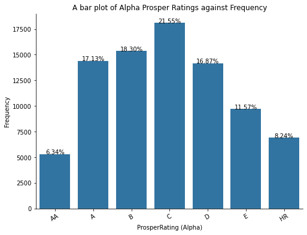

```python
# A bar plot showing borrowers prosper ratings.
bar_texts(prosper_loan['ProsperRating (Alpha)'], 'ProsperRating (Alpha)')
plt.title('A bar plot of Alpha Prosper Ratings against Frequency')
plt.ylabel('Frequency');
```

In the above plot, we can see that a larger number of Borrowers amounting to **73.85%** were those with an Alpha Prosper Rating of `A`, `B`, `C` and `D` with the largest number at **21.55%** being with a `C` alpha rating.

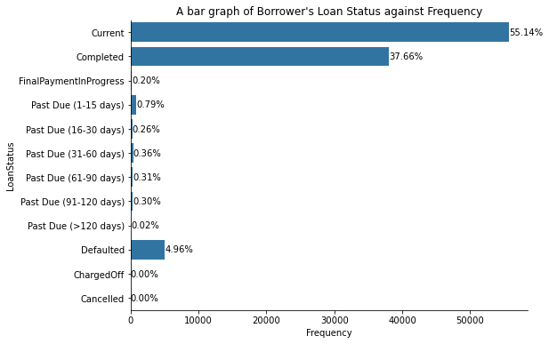

```python
# A horizontal bar plot showing borrowers loan statuses.
barh_texts(prosper_loan.LoanStatus, 'LoanStatus')
plt.title('A bar graph of Borrower\'s Loan Status against Frequency')
plt.xlabel('Frequency');
```

The above plot shows Loan Statuses of the borrowers in the dataset. Majority of those borrowers are those who had an ongoing loan, that is, investors had lent them money. A significant number of borrowers had completed paying their loans while **4.96%** of borrowers had defaulted.

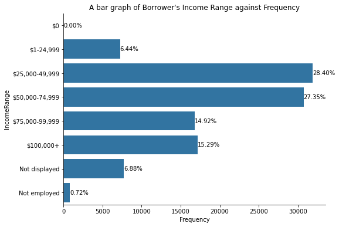

```python
# A bar graph showing the borrowers income range.
barh_texts(prosper_loan.IncomeRange, 'IncomeRange')
plt.title('A bar graph of Borrower\'s Income Range against Frequency')
plt.xlabel('Frequency');
```

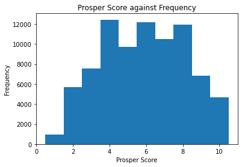

```python
# A plot of a histogram showing the distribution of borrowers with respect to their numeric Prosper score.
bins = np.arange(0.5, 10.5+1, 1)
plt.hist(data= prosper_loan, x= 'ProsperScore', bins= bins)
plt.xlabel('Prosper Score')
plt.ylabel('Frequency')
plt.title('Prosper Score against Frequency');
```

In the figure above, shows that a majority of the borrowers in the dataset are those who had ratings of `4`, `6` and `8`. Since the numeric Propser Score is of the discrete numeric type data, the edges in the plot had to be shifted to the left by 0.5 to remove ambiguity.

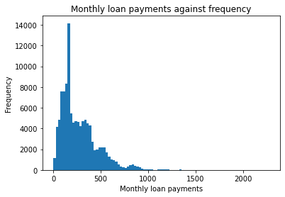

```python
# A histogram showing the distribution of monthly loan payments.
bins = np.arange(prosper_loan.MonthlyLoanPayment.min(), prosper_loan.MonthlyLoanPayment.max()+25, 25)
plt.hist(data= prosper_loan, x= 'MonthlyLoanPayment', bins= bins)
plt.xlabel('Monthly loan payments')
plt.ylabel('Frequency')
plt.title('Monthly loan payments against frequency');
```

The figure above shows the distribution of the borrowers monthly loan payments. It can be seen that a majority of the payed around **$200** every month. The distribution is also skewed to the right.

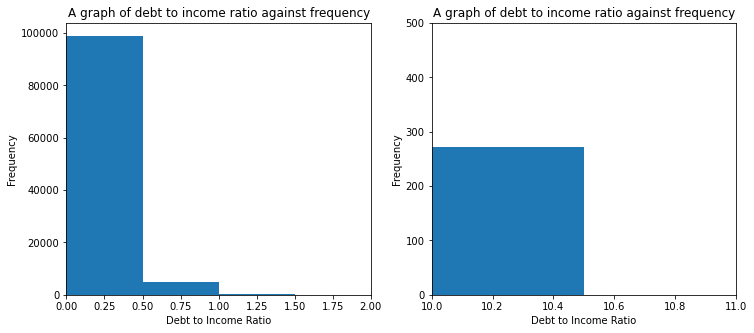

```python
# A histogram showing a histogram of borrowers debt to income ratio.
plt.figure(figsize= (12, 5))
plt.subplot(1, 2, 1)
bins = np.arange(prosper_loan.DebtToIncomeRatio.min(), prosper_loan.DebtToIncomeRatio.max()+0.5, 0.5)
plt.hist(data= prosper_loan, x= 'DebtToIncomeRatio', bins= bins)
plt.xlabel('Debt to Income Ratio')
plt.ylabel('Frequency')
plt.xlim(0, 2)
plt.title('A graph of debt to income ratio against frequency');

plt.subplot(1, 2, 2)
plt.hist(data= prosper_loan, x= 'DebtToIncomeRatio', bins= bins)
plt.xlabel('Debt to Income Ratio')
plt.ylabel('Frequency')
plt.xlim(10, 11)
plt.ylim(0, 500)
plt.title('A graph of debt to income ratio against frequency');
```

The graph above shows that the distribution have a large distibution between 0 and 0.5 for the first subplot. I had to make adjustments on the limit of the y-axis to have the graph seen clearly as there were less than 300 borrowers who had a debt to income ratrio of above 10.

I therefore have to make a square root transformation as for since the minimum value is 0 and the log of 0 is negative infinity.

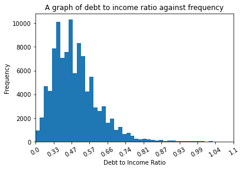

```python
def sqrt_transform(x, inverse= False):
    if not inverse:
        return np.sqrt(x)
    else:
        return np.power(x, 2)

# A histogram showing the distribution of borrowers Debt to Income Ratio.
bins = np.arange(prosper_loan.DebtToIncomeRatio.min(), sqrt_transform(prosper_loan.DebtToIncomeRatio.max())+0.025, 0.025)
plt.hist(data= prosper_loan, x= 'DebtToIncomeRatio', bins= bins);
plt.xlim(0, 1.2)
ticks = np.linspace(0, 1.2, 12)
plt.xticks(ticks, np.around(sqrt_transform(ticks), 2), rotation= 30)
plt.xlabel('Debt to Income Ratio')
plt.ylabel('Frequency')
plt.title('A graph of debt to income ratio against frequency');
```

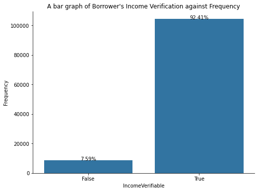

```python
# A bar graph showing distribution of of borrowers with respect to their verifiable income.
bar_texts(prosper_loan.IncomeVerifiable.astype(str), 'IncomeVerifiable')
plt.title('A bar graph of Borrower\'s Income Verification against Frequency')
plt.ylabel('Frequency')
plt.xticks(rotation= 0);
```

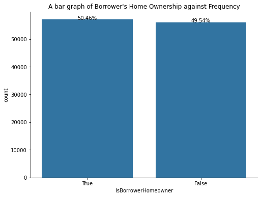

```python
# A bar graph showing Number of borrowers who are home owners.
bar_texts(prosper_loan.IsBorrowerHomeowner.astype(str), 'IsBorrowerHomeowner')
plt.title('A bar graph of Borrower\'s Home Ownership against Frequency')
plt.xticks(rotation= 0);
```

The graph above shows that a majority of the loan borrowers are home owners but by a small margin.

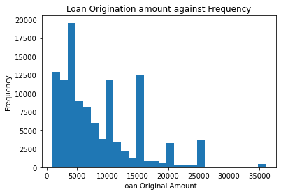

```python
# A histogram showing the distribution Loan's original amount.
bins = np.arange(prosper_loan.LoanOriginalAmount.min(), prosper_loan.LoanOriginalAmount.max()+1250, 1250)
plt.hist(data= prosper_loan, x= 'LoanOriginalAmount', bins= bins)
plt.xlabel('Loan Original Amount')
plt.ylabel('Frequency')
plt.title('Loan Origination amount against Frequency');
```

In the above histogram, we can see that the distribution of the borrowers loan original amount was skewed to the right with a majority of the amount being about $5000$ with sharp spikes at multiples of $5000$.

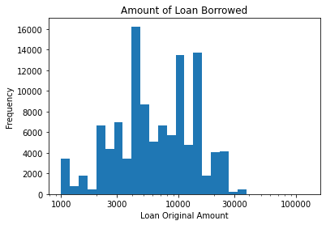

```python
# A histogram shown loan original amount using an log xscale.
x = np.log10(prosper_loan.LoanOriginalAmount.describe())
bins = 10 ** np.arange(x.min(), x.max()+0.075, 0.075)
plt.hist(data= prosper_loan, x= 'LoanOriginalAmount', bins= bins)
plt.xscale('log')
x_ticks = [1000, 3000, 10000, 30000, 100000]
plt.xticks(ticks= x_ticks, labels= x_ticks)
plt.xlabel('Loan Original Amount')
plt.ylabel('Frequency')
plt.title('Amount of Loan Borrowed');
```

```
0
```

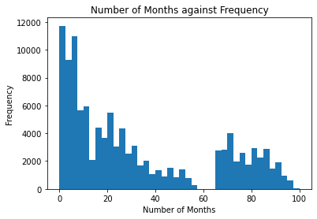

```python
# Number of borrowers with loans between 58 and 64 months since loan origination.
print(prosper_loan[(prosper_loan.LoanMonthsSinceOrigination > 58)&(prosper_loan.LoanMonthsSinceOrigination < 65)].LoanMonthsSinceOrigination.count())

# A histogram distribution of Number of months against Frequency.
bins = np.arange(prosper_loan.LoanMonthsSinceOrigination.min(), prosper_loan.LoanMonthsSinceOrigination.max()+2.5, 2.5)
plt.hist(data= prosper_loan, x= 'LoanMonthsSinceOrigination', bins= bins)
plt.xlabel('Number of Months')
plt.ylabel('Frequency')
plt.title('Number of Months against Frequency');
```

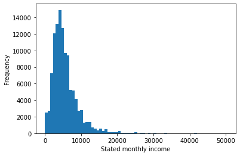

```python
# A histogram showing the ditribution of stated monthly salaries against frequency.
prosper_loans = prosper_loan[prosper_loan.StatedMonthlyIncome <= 50000]
bins = np.arange(prosper_loans.StatedMonthlyIncome.min(), prosper_loans.StatedMonthlyIncome.max()+750, 750)
plt.hist(data= prosper_loans, x= 'StatedMonthlyIncome', bins= bins)
plt.xlabel('Stated monthly income')
plt.ylabel('Frequency');
```

The above histogram shows that the distribution of the stated monthly income was skewed to the right with a majority of the borrowers stating their monthly income as about $\$4000$. However, there were outliers of amounts above $\$50000$. I therefore had to remove them.

### Discuss the distribution(s) of your variable(s) of interest. Were there any unusual points? Did you need to perform any transformations?

Most of the data in the dataset had distributions that were skewed to the right and thus I had to perform log transformations.

### Of the features you investigated, were there any unusual distributions? Did you perform any operations on the data to tidy, adjust, or change the form of the data? If so, why did you do this?

For the debt to income ratio, I had to do a squareroot transformation since there were values that had a zero and performing a log transformation meant that the minimum values could be up to negative infinity.

For the stated monthly income column, I had to remove the outliers of values that were above $\$50,000$.

## Bivariate Exploration

I will start by looking at the correlations between the numeric variables stated below.

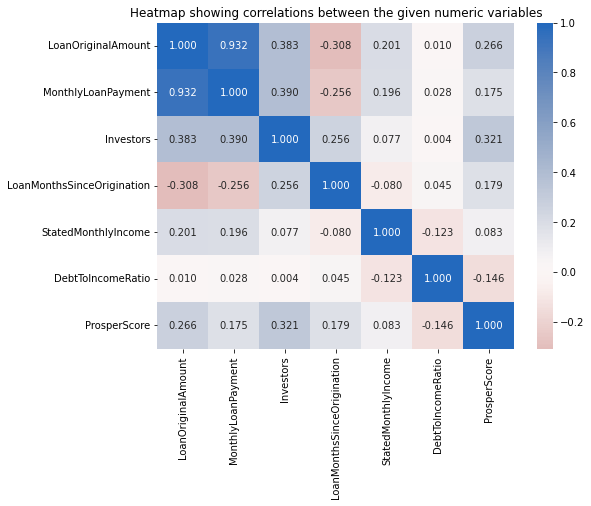

```python
# A heatmap showing the correlations between the numeric variables shown below.
numeric_vars = ['LoanOriginalAmount', 'MonthlyLoanPayment', 'Investors', 'LoanMonthsSinceOrigination', 'StatedMonthlyIncome',
               'DebtToIncomeRatio', 'ProsperScore']
plt.figure(figsize= (8, 6))
g = sb.heatmap(data= prosper_loan[numeric_vars].corr(), annot= True, fmt= '.3f', center= 0, cmap= 'vlag_r')
plt.title('Heatmap showing correlations between the given numeric variables');
```

From the figure above, we can see how the numeric variables correlate with each other. There was one strong correlation between monthly loan payments and loan original amount. Other correlations were weak ranging from about -0.3 to 0.4.

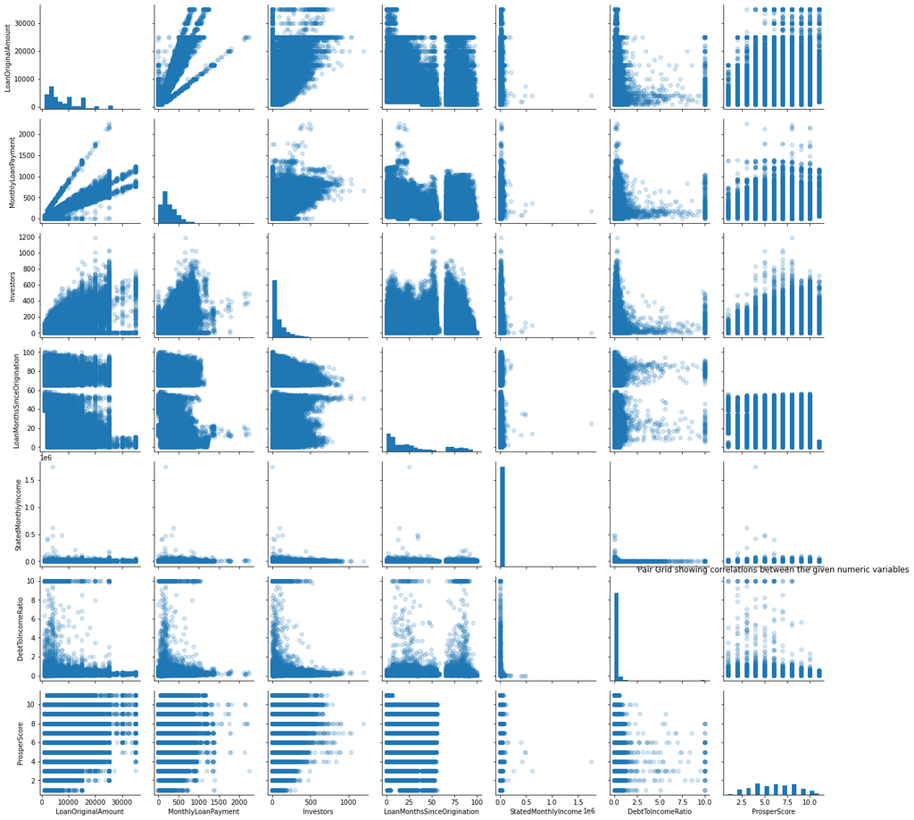

```python
# A pair grid showing the correlations between the numeric variables stated above.
g = sb.PairGrid(data= prosper_loan, vars= numeric_vars)
g.map_diag(plt.hist, bins= 20)
g.map_offdiag(plt.scatter, alpha= 1/5)
plt.title('Pair Grid showing correlations between the given numeric variables');
```

The plot matrix above shows relationships between different numeric variables.

The relationship between Monthly Loan Payments with Loan Original Amount stands out as both are highly correlated with each other. Most of the other variables are weakly correlated with each other.

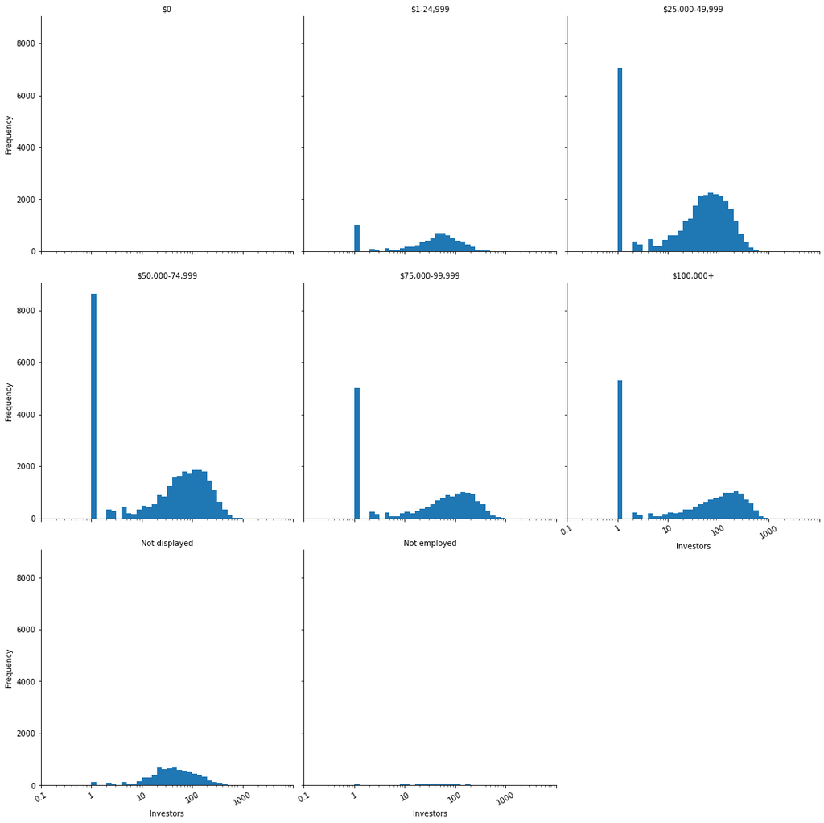

```python
# A FacetGrid showing the relationship between Borrowers' Income range and Investors.
base_color = sb.color_palette()[0]
x = np.log10(prosper_loan.Investors.describe())
bins = 10 ** np.arange(x.min(), x.max() + 0.1, 0.1)
g = sb.FacetGrid(data= prosper_loan, col= 'IncomeRange', col_wrap= 3, size= 5)
g.map(plt.hist, 'Investors', bins= bins)
x_ticks = [0.1, 1, 10, 100, 1000]
g.set(xticks= x_ticks, xscale= 'log', xlim= (1, 1000), xticklabels= x_ticks)
g.set_axis_labels('Investors', 'Frequency')
g.set_xticklabels(rotation= 30)
g.set_titles('{col_name}');
```

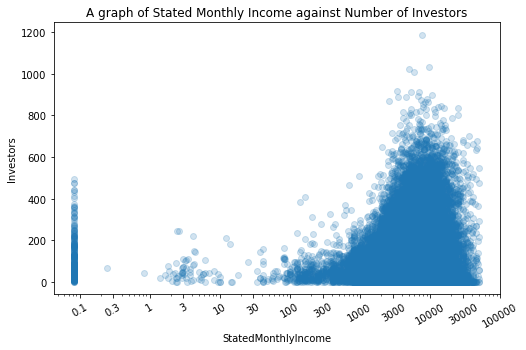

```python
# A scatter plot showing the relationship between stated monthly income against investors
plt.figure(figsize= (8, 5))
sb.regplot(data= prosper_loans, y= 'Investors', x= 'StatedMonthlyIncome', scatter_kws= {'alpha' : 1/5},
          fit_reg= False)
plt.xscale('log')
x_ticks = [0.1, 0.3, 1, 3, 10, 30, 100, 300, 1000, 3000, 10000, 30000, 100000]
plt.xticks(ticks= x_ticks, labels= x_ticks, rotation= 30)
plt.title('A graph of Stated Monthly Income against Number of Investors');
```

The graph above shows that for borrowers who stated their monthly income as $\$0$ had a range of $0$ to about $500$ investors loan them money. Of those borrowers, a majority of them had less than $200$ investors loan them money.

The number of investors seems to be increasing with an increasing number of the stated monthly income with the peak being at about $\$10,000$. Even then, only a few of those borrowers had more than $600$ investors loan them money.

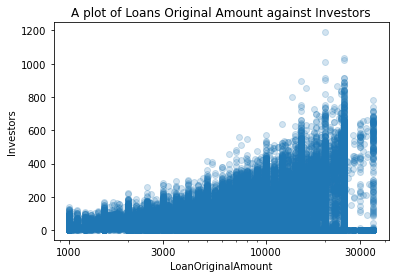

```python
# A scatterplot to show how Original Loan Amouts relate with Number of Investors
sb.regplot(data= prosper_loan, y= 'Investors', x= 'LoanOriginalAmount', scatter_kws= {'alpha' : 1/5}, fit_reg= False)
plt.xscale('log')
x_ticks = [1000, 3000, 10000, 30000]
plt.xticks(ticks= x_ticks, labels= x_ticks)
plt.title('A plot of Loans Original Amount against Investors');
```

The above plot shows that the number of investors giving borrowers loans increased as the number of the original loan amount increased. For borrowers who needed about $\$1000$ sent to them had less than $200$ investors loan them money.

However, most borrowers with a loan of above $\$10,000$ had less than $500$ investors while just a few of them had more than $600$ investors. Majority of the borrowers with an original loan amount of $\$30,000$ had only one investor.

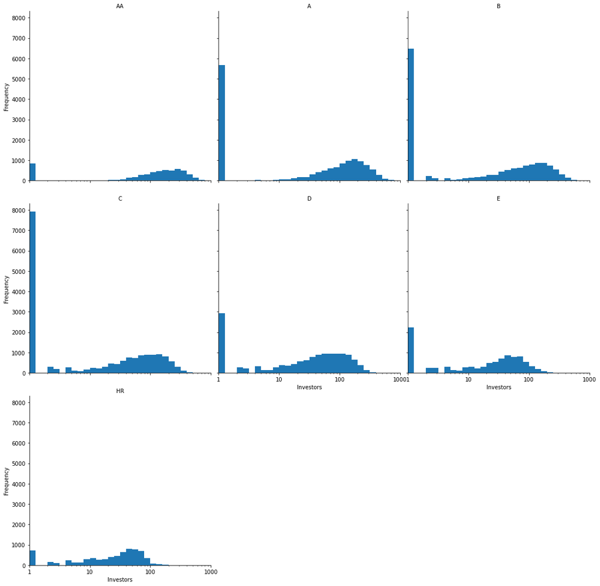

```python
# A boxplot to show how the Alpha Prosper Ratings relate with Number of Investors
plt.figure(figsize= (12, 5));
base_color = sb.color_palette()[0]
x = np.log10(prosper_loan.Investors.describe())
bins = 10 ** np.arange(x.min(), x.max() + 0.1, 0.1)
g = sb.FacetGrid(data= prosper_loan, col= 'ProsperRating (Alpha)', col_wrap= 3, size= 5);
g.map(plt.hist, 'Investors', bins= bins);
x_ticks = [1, 10, 100, 1000]
g.set(xscale= 'log', xticks= x_ticks, xticklabels= x_ticks, xlim= (1, 1000));
g.set_axis_labels('Investors', 'Frequency');
g.set_titles('{col_name}');
```

A majority of the borrowers with an `A`, `B` and `C` alpha prosper rating had the majority of investors. In most groups, majority of the investors had only one investor. There were small heaps showing an increase in the number of investors with a count of less than 1000 for every rating.

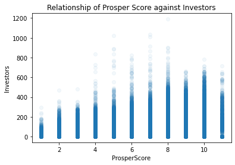

```python
# A scatterplot to show how scores given by Prosper relate with Number of Investors.
sb.regplot(data= prosper_loan, x= 'ProsperScore', y= 'Investors', scatter_kws= {'alpha' : 1/20}, fit_reg= False)
plt.title('Relationship of Prosper Score against Investors');
```

A borrower with a prosper rating of 8 had the most number of investors, that is 1200. It can also be seen that less borrowers had more than 600 investors lending them loans.

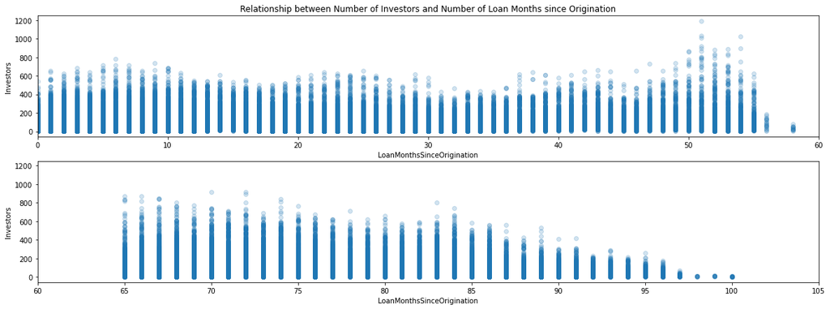

```python
# A scatterplot to show how Number of Months since Origination relate with Number of Investors
plt.figure(figsize= (20, 7))
plt.subplot(2, 1, 1)
sb.regplot(data= prosper_loan, x= 'LoanMonthsSinceOrigination', y= 'Investors', fit_reg= False,
          scatter_kws= {'alpha' : 1/5})
plt.title('Relationship between Number of Investors and Number of Loan Months since Origination')
plt.xlim(0, 60);

plt.subplot(2, 1, 2)
sb.regplot(data= prosper_loan, x= 'LoanMonthsSinceOrigination', y= 'Investors', fit_reg= False,
          scatter_kws= {'alpha' : 1/5})
plt.xlim(60);
```

It is notable that at about 59 to 64 months since loan origination there were no borrowers who had requested for loans at that time from the graph shown above.

For the borrowers with more than 65 months since loan origination, the number of borrowers seems to have been decreasing with increase in the number of months.

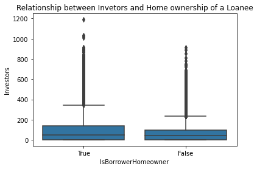

```python
# A box plot showing the relationship between ownership of a home by a borrower and the number of investors.
base_color = sb.color_palette()[0]
sb.boxplot(data= prosper_loan, x= 'IsBorrowerHomeowner', y= 'Investors', color= base_color)
plt.title('Relationship between Invetors and Home ownership of a Loanee');
```

From the above plot, for borrowers who owned homes, there were very many outliers in terms of the number of investors as compared to borrowers who did not own homes. The median of the number of investors who lent loans to borrowers who owned homes was slightly higher than those who did not own homes.

It is also evident that for borrowers who did owned homes, there was a larger interquartile range showing that most invetors lent people who owned homes loans as compared to borrowers who owned no homes.

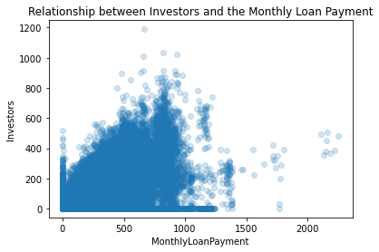

```python
# A scatter plot showing the relationship between the monthly loan payments and number of investors.
sb.regplot(data= prosper_loan, x= 'MonthlyLoanPayment', y= 'Investors', fit_reg= False, scatter_kws= {'alpha' : 1/5})
plt.title('Relationship between Investors and the Monthly Loan Payment');
```

From the above plot, it can be seen that a majority of the borrowers who made payments of about less $\$1250$ a month had at least one investor.

Quite a significant number of borrowers had at least one investor yet they made no monthly payments.

It is also notable that a majority of the number of investors were clustered where borrowers made less than $\$1000$ monthly.

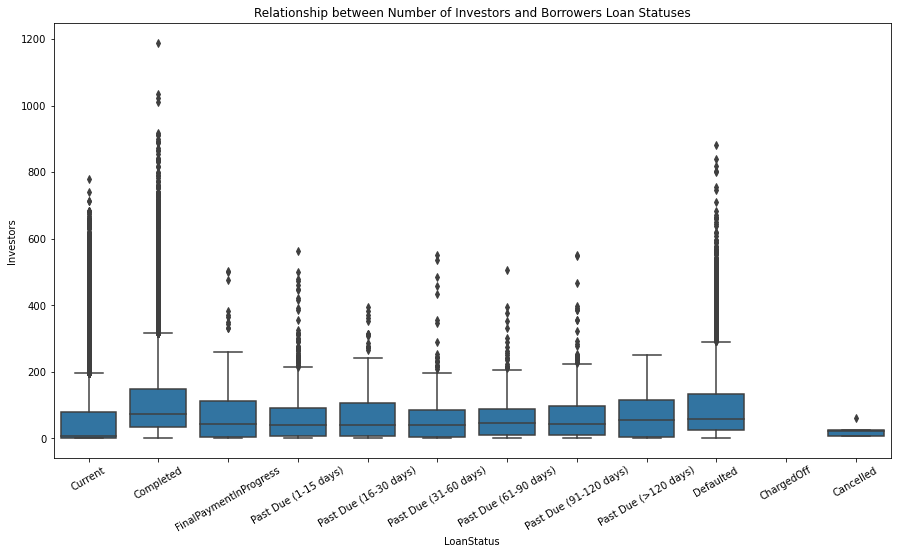

```python
# Boxplots showing the relationships between borrowers loan statuses and number of investors.
plt.figure(figsize= (15, 8))
base_color = sb.color_palette()[0]
sb.boxplot(data= prosper_loan, x= 'LoanStatus', y= 'Investors', color= base_color)
plt.xticks(rotation= 30)
plt.title('Relationship between Number of Investors and Borrowers Loan Statuses');
```

The above figure shows that for borrowers who had completed their loan payments had the most number of outliers and the highest median followed closely by those who had defaulted.

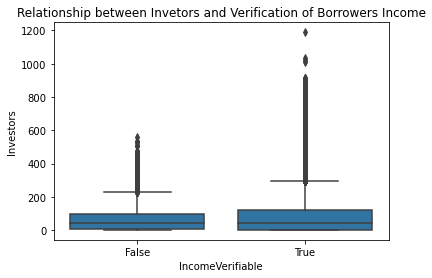

```python
# A boxplot showing the relationship between borrowers income verification and number of investors.
base_color = sb.color_palette()[0]
sb.boxplot(data= prosper_loan, x= 'IncomeVerifiable', y= 'Investors', color= base_color)
plt.title('Relationship between Invetors and Verification of Borrowers Income');
```

The above plot shows that most of the borrowers who had their source(s) of income verified had the most outliers in terms of number of investors. However the median number of investors was just about the same although the interquartile range in number of investors was quite significant for borrowers who had their source(s) of income verified.

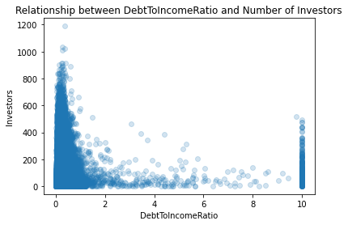

```python
# A scatter plot showing the relationship between number of investors and the debt to income ratio.
sb.regplot(data= prosper_loan, y= 'Investors', x= 'DebtToIncomeRatio', fit_reg= False, scatter_kws= {'alpha' : 1/5})
plt.title('Relationship between DebtToIncomeRatio and Number of Investors');
```

From the above plot, it's evident that people with a small debt to income ratio had the most number of investors as compared to those with a low debt to income ratio. For borrowers with a debt to income ratio of 10 had a significant number of investors lending them money.

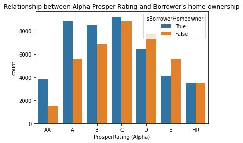

```python
# A plot showing the relation between two categorical variables.
sb.countplot(data= prosper_loan, x= 'ProsperRating (Alpha)', hue= 'IsBorrowerHomeowner')
plt.title('Relationship between Alpha Prosper Rating and Borrower\'s home ownership');
```

The plot above shows the relationship between ownership of a home by the borrower and their Alpha prosper rating. Of the first four high ratings, `AA` `A` `B` and `C`, majority of the borrowers owned homes while for the borrowers who had low ratings of `D` and `E`, majority of them didn't own homes. As for the prosper rating `HR`, the number of borrowers who owned homes and those who didn't was the same.

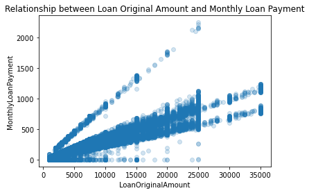

```python
# A scatter plot of monthly loan payment and loan original amount.
sb.regplot(data= prosper_loan, x= 'LoanOriginalAmount', y= 'MonthlyLoanPayment', fit_reg= False, scatter_kws= {'alpha' : 1/5})
plt.title('Relationship between Loan Original Amount and Monthly Loan Payment');
```

### Talk about some of the relationships you observed in this part of the investigation. How did the feature(s) of interest vary with other features in the dataset?

Some of the features I investigated were the relationships between the Alpha ProsperRating against home ownership of the borrowers, where majority of home owners had a higher alpha prosper rating while those who didn't own homes had a lower alpha prosper rating.

For the relationship between debt to income ratio and number of investors, borrowers with a small number of investors seem to have had a larger number of investors compared to people with a higher debt to income ratio with an exception of a debt to income ratio of 10.

For the relationship between number of investors and the stated monthly income, people with a higher stated monthly income seem to attract quite a large number of investors as compared to those with a smaller stated monthly income. However, there seems to be an exception when it comes to people with a stated monthly income of 0.

### Did you observe any interesting relationships between the other features (not the main feature(s) of interest)?

There is a very interesting relationship between the monthly loan payment and the loans original amount. The two are strongly correlated with a positive linear correlation. However there seems to be parts in the plot where there's no correlation between the two variables as some borrowers did not make any monthly loan payments.

## Multivariate Exploration

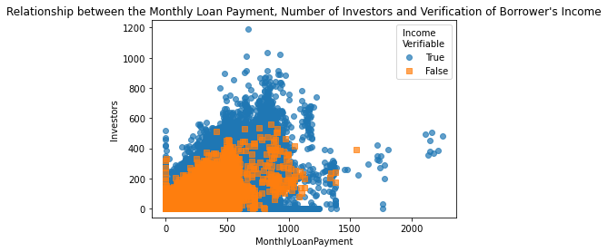

```python
# A plot showing the relationship between Monthly Loan Payment, Number of Investors and Verification of Borrower's Income
cat_markers = [[True, 'o'],
               [False, 's']]

for cat, marker in cat_markers:
    prosper_cat = prosper_loan[prosper_loan.IncomeVerifiable == cat]
    plt.scatter(data = prosper_cat, x = 'MonthlyLoanPayment', y = 'Investors', marker = marker, alpha= 0.7)
plt.xlabel('MonthlyLoanPayment')
plt.ylabel('Investors')
plt.title('Relationship between the Monthly Loan Payment, Number of Investors and Verification of Borrower\'s Income')
plt.legend(['True','False'], title= 'Income\nVerifiable');
```

From the plot above, most investors lent their money to borrowers who had their source(s) of income verified throughout the dataset. Also, for borrowers who could do a monthly loan payment of more than $\$1750$ all had their source(s) of income verified.

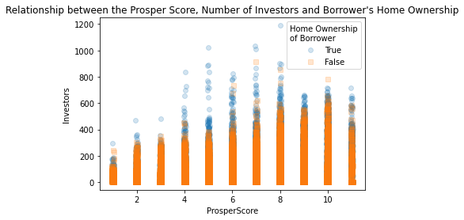

```python
# A plot to show the Relationship between the Prosper Score, Number of Investors and Borrowers Home Ownership
cat_markers = [[True, 'o'],
               [False, 's']]

for cat, marker in cat_markers:
    prosper_cat = prosper_loan[prosper_loan.IsBorrowerHomeowner == cat]
    sb.regplot(data = prosper_cat, x = 'ProsperScore', y = 'Investors', marker = marker, x_jitter= 1/20, fit_reg= False,
              scatter_kws= {'alpha' : 1/5})
plt.xlabel('ProsperScore')
plt.ylabel('Investors')
plt.title('Relationship between the Prosper Score, Number of Investors and Borrower\'s Home Ownership')
plt.legend(['True','False'], title= 'Home Ownership\nof Borrower');
```

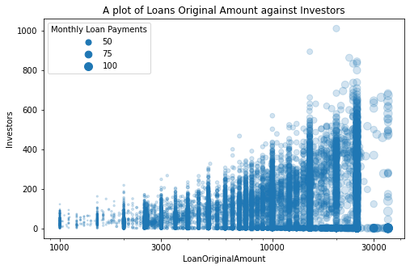

```python
# Getting the state with the most number of borrowers.
most_borrower_state = prosper_loan[prosper_loan.BorrowerState == prosper_loan.BorrowerState.value_counts().index[0]]

# A scatter plot showing the relationship between Investors and Loan Original Amount.
plt.figure(figsize= (8, 5))
sb.regplot(data= most_borrower_state, y= 'Investors', x= 'LoanOriginalAmount', x_jitter= 0.3,
           scatter_kws= {'alpha' : 1/5 , 's' : most_borrower_state['MonthlyLoanPayment']/10}, fit_reg= False);
plt.xscale('log');
size = [50, 75, 100]
base_color = sb.color_palette()[0]
legend = []
for s in size:
    legend.append(plt.scatter([], [], s= s, color= base_color))

plt.legend(legend, size, title= 'Monthly Loan Payments');
x_ticks = [1000, 3000, 10000, 30000];
plt.xticks(ticks= x_ticks, labels= x_ticks);
plt.title('A plot of Loans Original Amount against Investors');
```

From the above plot, we can see that the relationship between number of investors in the newly formed dataset, of the state with the most number of borrowers, increases with an increase in the number of loan original amount. The amount of monthly loan payments seems to have been increasing with an increase in the loan original amount as well as an increase in the number of investors.

### Talk about some of the relationships you observed in this part of the investigation. Were there features that strengthened each other in terms of looking at your feature(s) of interest?

I got to observe the relationships between number of investors, monthly loan payment and verification of borrowers source(s) of income where it was evident that for borrowers whose income verification was **False** did not have more than about $500$ investors lending them loans. Also, most borrowers who had more than $600$ invetors lending them money all had their sources of income verified.

I also went ahead and determined the relationship between the number of investors, the numeric prosper rating and the home ownership of a borrower. In this case, majority of the borrowers who had a high rating had the majority of investors lending them loans. However, more investors invested lent borrowers with a home ownership compared to owners without home ownership.

I also got to investigate the relationship between number of investors, the original loan amount and the monthly loan payments in the state with the most number of borrowers where the monthly loan payments seemed to be increase with an increase in the original amount of the loan borrowed. That also attracted an increase in the number of investors.

### Were there any interesting or surprising interactions between features?

An interesting result in the third multivariate visualization is that a majority of the borrowers borrowed less than $\$30000$ with those who borrowed an original amount $\$30000$ or more all seem to be having a return of a large sum of money in their monthly loan payments with the majority of those borrowers having only one investor lending them loans.

## Conclusions

The dataset is from a US based peer-to-peer lending marketplace as all borrowers are from states from the US.